# Weather Impact on Citibike Ridership

Harish Visweswaran, Phani Valasa, Rohit Dalal, Venkat Gangireddy

## 1. Introduction

Human mobility is NYC is complex and dynamically changing. In the past couple of years, bike-sharing has taken a major role in the transportation network of big cities as an alternative way of getting around the city. Prior to these times, taxi service was the primary ground transportation. Weather plays a key role in influencing the mode of commute. Several weather variables, including precipitation, sunshine, snow, wind speed and temperature have been shown to influence participation in bicycling.

Bicycling is a widely used form of physical activity. It has been linked to lower risks of cardiovascular disease, diabetes, cancer, hypertension, obesity and depression. Analyzing the impact of weather on bike ridership and taxi service, would help to understand the NYC commuter physical acitivity. It is also important for the Citi Bike business and for policymakers to be more aware of how individuals behave when they expect certain weather conditions and if this plays a role in individuals finding other forms of transportation that does not rely on being outdoors while commuting. This motivated us to further dig deep on this subject and answer the following:

1. What is the general ridership pattern for citibike rides in the New York City area through different months of the year 2018?
2. What is the effect of weather on citibike ridership volume in NYC ?
3. How does weather impact the duration of the rides? Do people only opt for shorter rides during cold/rainy or adverse weather or is the length of the ride not affected?
4. Do we see a relationship between citibike ridership in NYC and NYC taxi ridership? Does weather affect their relationship?

#### Team (in alphabetical order)

1. Harish Babu Visweswaran (hv2197)
2. Phani Valasa (pkv2103)
3. Rohit Dalal (rd2805)
4. Venkat Gangireddy (vrg2114)

All of us collabrated together on formalizing the questions and the overall layout of the project. Three of us were assigned to the discovery, understanding, ingestion and analysis of the appropriate portion of the datasets. Phani ingested and explored Citibike data, Harish worked on the Weather dataset and Rohit focused on ingesting and analyzing Yellow Cab data and putting together final report by working along with others. Venkat worked on the development of the Shiny app.

We tried to distribute the project work evenly among all the team members.

#### Github Repo

https://github.com/harish-cu/edav_fall_2019_citibike_weather

## 2. Data Sources

Three datasets have been used to support our analysis. In an effort to streamline our effort, we have focused on NYC Manhattan borough data and also filtered out any column that would be unhelpful in answering our specific questions.

**1. Citibike:** Citibike ridership data is available as a monthly zipped .csv file on the citibike website: https://www.citibikenyc.com/system-data. We have used data for entire calendar year 2018, below have been identied as key data elements after prepping up data for analysis.

- Ride Date
- Ride Hour
- Start Station
- Geo-Codes (Long & Lat)
- Total Rides
- Min Ride Duration
- Max Ride Duration
- Avg Ride Duration

**2. Yellow Cab:** Yellow Cab trips data is also available as a monthly .csv file on NYC, Taxi & Limousine Commission official website: https://www1.nyc.gov/site/tlc/about/tlc-trip-record-data.page. Taxi zone mapping .csv file can also be obtained from here. Due to the extremly large volume of Yellow cab trips for calendar year 2018 (112 M records), we decided to use data for Nov 2018. Below have been identied as key data elements after prepping up data for analysis.

- Pickup Date
- Pickup Hour
- Pickup Location
- Zone
- Total Trips
- Min Trip Duration
- Max Trip Duration
- Avg Trip Duration

**3. Weather:** Weather data is obtained as .csv file from NOAA website :https://www.ncdc.noaa.gov/. In order to obtain the dataset, follow below steps:

- Go to https://www.ncdc.noaa.gov/cdo-web/search
- For the dropdown *Select Weather Observation Type/Dataset, choose **Daily Summaries*
- For the dropdown *Select Date Range*, choose the appropriate Date Range. For this analysis, we used the data for the entire calendar year 2018
- For the dropdown *Search For, select **Stations*
- For the dropdown *Enter a Search Term, enter **JFK* in order to search for the station at JFK INTERNATIONAL AIRPORT
- This will take you to a Map View focused on the weather station at JFK. Either use the side bar to select the station and add the data to cart or click on the JFK station pin on the map and hit the button *add to cart*.
- Go to the cart and select the CSV version of the file for downloads and then hit *Continue*
- In the next screen, select all the fields under *Station Detail & Data Flag Options* and under *Select data types for custom output* and then hit *Continue*
- In the following screen, enter your email address and hit *Submit Order* to receive the file. The file is usually processed and sent in a couple of minutes

## 3. Data Transformation

Using raw data files from each source described earlier, below code generates summary data for Yellow Cab, Citibike and Weather. Summary output for each is stored as .csv file, files can be downloaded from our project github repo.

```r
library(tidyverse)
library(GGally)
library(vcd)
library(extracat)
library(lubridate)
library(parcoords)
```

#### Citibike

- Below function reads all monthly citibike raw data files for 2018 and combines them to create summary reports at date and date + gender level. **Code has been commented out while rendering HTML as it takes long time to process large size raw data files.**

```r
# # Summarize the data for the 2018 datasets at the date level.
# summary <- function(filename){
#   df_data <- read.csv(file = filename)
#   df_grp <- df_data %>%
#   mutate(Date = date(starttime)) %>%
#   mutate(start.station.id = as.character(start.station.id)) %>%
#   group_by(Date, start.station.id, start.station.latitude, start.station.longitude) %>%
#   summarise(min_duration=min(tripduration), max_duration =max(tripduration), avg_duration=mean(tripduration),trip_count=n()) %>%
#   ungroup() %>%
#   select(Date, start.station.id, start.station.latitude, start.station.longitude,min_duration,max_duration, avg_duration,trip_count)
# return(df_grp)
# }
#
# # Summarize the data for the 2018 datasets at the date and gender level.
# summary_age <- function(filename){
#   df_data <- read.csv(file = filename)
#   df_grp <- df_data %>%
#   mutate(startDate = as.Date(starttime)) %>%
#   mutate(date = date(starttime)) %>%
#   mutate(age = (floor((2018-birth.year)/10))*10 ) %>%
#   group_by(date, gender, age) %>%
#   summarise(min_duration=min(tripduration), max_duration =max(tripduration), avg_duration=mean(tripduration),trip_count=n()) %>%
#   ungroup() %>%
#   select(date, gender, age,min_duration,max_duration, avg_duration,trip_count)
# return(df_grp)
# }
#
# # Directory where raw files are stored
# mypath = "~/Documents/"
# filenames <- list.files(path=mypath, full.names=TRUE)
#
# datalist <- lapply(filenames, function(x){summary(x)})
# datalist1 <- datalist %>% reduce(bind_rows)
# write.csv(datalist1,'~/Documents/2018-citibike-summarydata.csv')
#
# datalist_age <- lapply(filenames, function(x){summary_age(x)})
# datalist_age1 <- datalist_age %>% reduce(bind_rows)
# write.csv(datalist_age1,'~/Documents/2018-citibike-summarydata-age-gender.csv')
```

#### Yellow Cab

- Merged Yellow Cab data with taxi zones to map pickup and dropoff locations.

```r
# Raw Data
df_data_yc_nov <- read_csv(file="~/Documents/YellowCab_2018_11.csv")
df_taxi_zone <- read_csv(file="~/Documents/YellowCab_Taxi_Zones.csv")

# Merge
df_data_yc_select <- df_data_yc_nov[,c('tpep_pickup_datetime','tpep_dropoff_datetime', 'PULocationID','DOLocationID', 'trip_distance')]
df_data_yc_select <- setNames(df_data_yc_select, c("Pickup_Time","Dropoff_Time","Pickup_Loc", "Dropoff_Loc", "Distance"))
df_data_yc_merge<- merge(df_data_yc_select, df_taxi_zone, by="Pickup_Loc")
```

- Cleaned data by excluding invalid records which are not associated with the month of November.

```r
# Exclude data before 11/01/2018 (320 Records) and after 12/01/2018 (103 Records) from Nov file
df_data_yc_merge <- filter(df_data_yc_merge, Pickup_Time > as.Date("2018-11-01"))
df_data_yc_merge <- filter(df_data_yc_merge, Pickup_Time < as.Date("2018-12-01"))
```

- Summarized and saved in .csv file

```r
# Calculate additional columns and save the summary output in a CSV file
df_data_yc_merge<- df_data_yc_merge %>%
  mutate(Duration = as.numeric(Dropoff_Time - Pickup_Time)) %>%
  mutate(Pickup_Date = date(Pickup_Time)) %>%
  mutate(Pickup_Hour = hour(Pickup_Time)) %>%
  select(Pickup_Date, Pickup_Hour, Pickup_Loc, Zone, Distance, Duration)

# Summarize
df_data_yc_grp <- df_data_yc_merge %>%
  group_by(Pickup_Date, Pickup_Hour, Pickup_Loc, Zone) %>%
  summarise(min_duration=min(Duration), max_duration =max(Duration), avg_duration=mean(Duration),yc_trip_count=n())

# Save summary output in a CSV file
write.csv(df_data_yc_grp, file="~/Documents/YellowCab_2018_11_Summary.csv", row.names=FALSE)
```

#### Weather

- Weather data downloaded from the source is already summarized at daily level, no further action needed.

## 4. Missing Values

For all of the 3 datasets, we **DIDN’T** find any missing values in the raw datafiles obtained from the source. However, we identifed some outliers in the Citibike data related to rider’s age.

#### Citibike

```r
cb_raw <- read.csv(file="~/Documents/2018-citibike-tripdata.csv")
colSums(is.na(cb_raw)) %>% sort(decreasing=TRUE)
```

```
##            tripduration               starttime                stoptime
##                       0                       0                       0
##        start.station.id      start.station.name  start.station.latitude
##                       0                       0                       0
## start.station.longitude          end.station.id        end.station.name
##                       0                       0                       0
##    end.station.latitude   end.station.longitude                  bikeid
##                       0                       0                       0
##                usertype              birth.year                  gender
##                       0                       0                       0
```

**Age Outliers Boxplot**

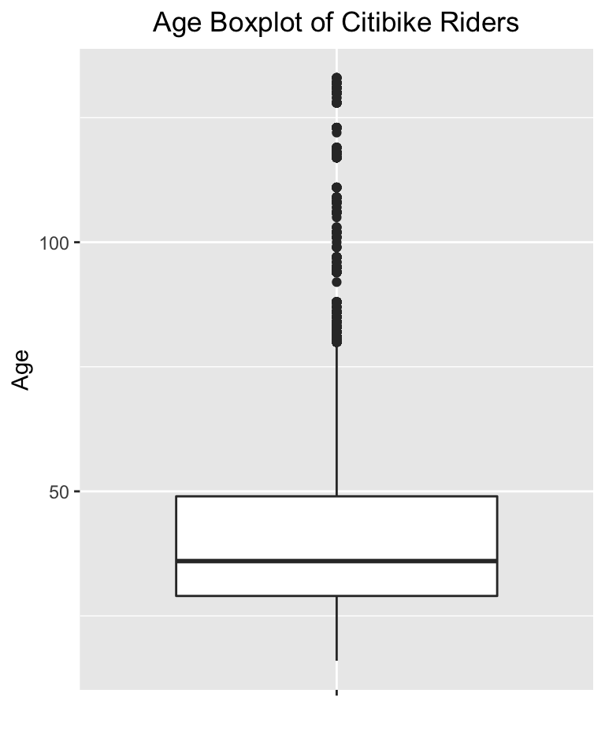

```r
# Citibike - Age outliers
cb_raw_with_age <- cb_raw %>%
  mutate(age = 2018-birth.year)

ggplot(data=cb_raw_with_age) +
  geom_boxplot(mapping=aes(x="", y=age)) +
    labs(title = "Age Boxplot of Citibike Riders",
       x = "",
       y = "Age") +
  theme(plot.title = element_text(hjust = 0.5))
```

#### Yellow Cab

```r
yc_raw <- read.csv(file="~/Documents/YellowCab_2018_11.csv")
colSums(is.na(yc_raw)) %>% sort(decreasing=TRUE)
```

```
##              VendorID  tpep_pickup_datetime tpep_dropoff_datetime
##                     0                     0                     0
##       passenger_count         trip_distance            RatecodeID
##                     0                     0                     0
##    store_and_fwd_flag          PULocationID          DOLocationID
##                     0                     0                     0
##          payment_type           fare_amount                 extra
##                     0                     0                     0
##               mta_tax            tip_amount          tolls_amount
##                     0                     0                     0
## improvement_surcharge          total_amount
##                     0                     0
```

#### Weather

```r
weather_raw <- read.csv(file="~/Documents/2018_Weather_NYC.csv")
colSums(is.na(weather_raw)) %>% sort(decreasing=TRUE)
```

```
##   STATION      NAME  LATITUDE LONGITUDE ELEVATION      DATE      AWND
##         0         0         0         0         0         0         0
##      PRCP      SNOW      SNWD      TAVG      TMAX      TMIN
##         0         0         0         0         0         0
```

## 5. Results

We read summary datafiles created earlier and further aggregates the data or even merge two or more datesets to help support our analysis to gain some preliminary insights into our questions.

```r
weather_nyc <- read_csv('https://raw.githubusercontent.com/harish-cu/edav_fall_2019_citibike_weather/master/data/raw/2018_Weather_NYC.csv')

weather_nyc$DATE <- mdy(weather_nyc$DATE)

# Filter for the time period of the analysis
weather_nyc <- weather_nyc %>%
  filter(DATE>='2018-01-01', DATE<'2019-01-01')

# Select the necessary variables
weather_nyc <- weather_nyc %>%
  select('DATE', 'PRCP', 'TAVG', 'TMAX' , 'TMIN', 'SNOW', 'SNWD', 'AWND')

weather_nyc <- weather_nyc %>%
  mutate(month = month(DATE, label=TRUE))

weather_nyc <- weather_nyc %>%
  mutate(dow = weekdays(weather_nyc$DATE, abbreviate = TRUE)) %>%
  mutate(is_weekend = ifelse(dow=="Sat"|dow=="Sun",1,0)) %>%
  mutate(is_sunday = ifelse(dow=="Sun",1,0))
```

While people are generally familiar with how the weather varies over the year in NYC, we want to set the table before we get into the effect of weather on ridershup. Here,we show the average temperature trend across the entire year of 2018.

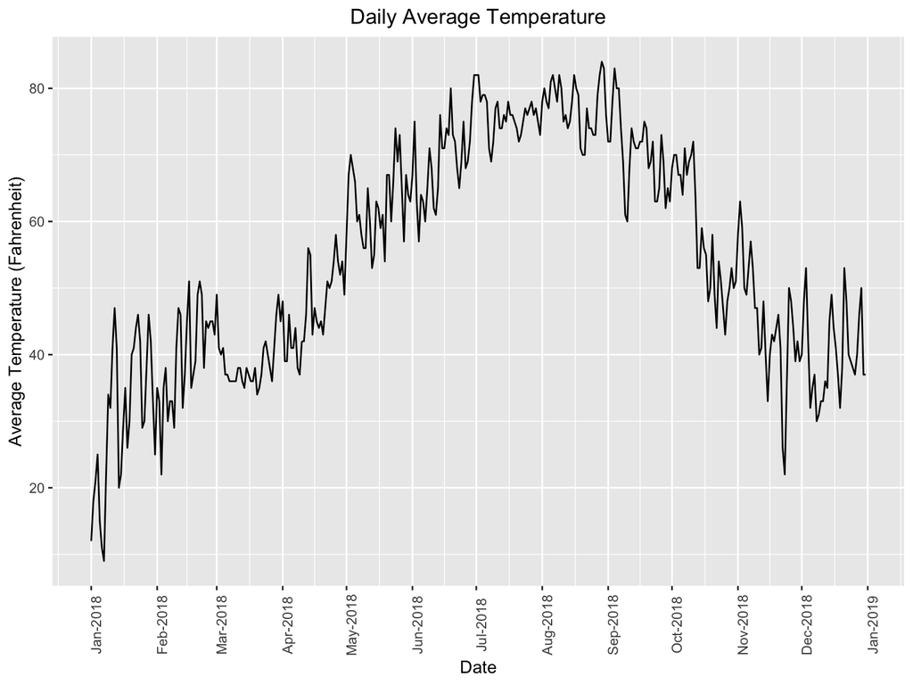

```r
ggplot(weather_nyc, mapping=aes(x=DATE, y=TAVG)) +
  geom_line() +
  scale_x_date(date_breaks = '1 month', date_labels = "%b-%Y") +
  labs(title = "Daily Average Temperature",
  x = "Date",
  y = "Average Temperature (Fahrenheit)") +
  theme(axis.text.x = element_text(angle = 90),
  plot.title = element_text(hjust = 0.5))
```

As expected, the temperatures are the low on the two ends of the graph (during the winter months of January, February, November and December) and high during the summer months (June, July, August and even September). The trend is pretty smooth (if we ignore the short term variations).

Note that this graph indicates the average daily temperature (temperature averaged across the different hours of the day). As a result, the temperature values on this graph may not be as high as people expect (low night temperatures bring the average for the day down) but this graph provides insight into how the temperature varies through different months of the year

Here is a look at the average temperature distribution by month. The boxplot helps us compare the median values across the months and also the variability in the average temperatures for each month.

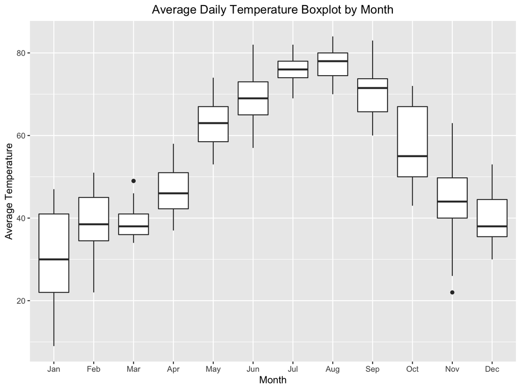

```r
ggplot(weather_nyc, mapping=aes(x=month, y=TAVG)) +
  geom_boxplot() +
  labs(title = "Average Daily Temperature Boxplot by Month",
  x = "Month",
  y = "Average Temperature") +
  theme(plot.title = element_text(hjust = 0.5))
```

We can clearly see the unimodal trend with the peaks in the summer months. Additionally, we can see that the month of January for 2018 had high variability in the daily average temperature. This is not surprising because of the arctic blast that the US experienced in 2018 that affected the weather for quite a few days. Feel free to check out the article listed here to read more about the arctic blast.

https://weather.com/storms/winter/news/2018-01-01-arctic-record-cold-outbreak-forecast-midwest-east-south-early-january

Apart from January, we see that the temperature variation is high in October too. October is one of the transition months that brings us from the summer to the winter, so it isn’t very surprising either.

Similarly, we plot the total precipitation for each day.

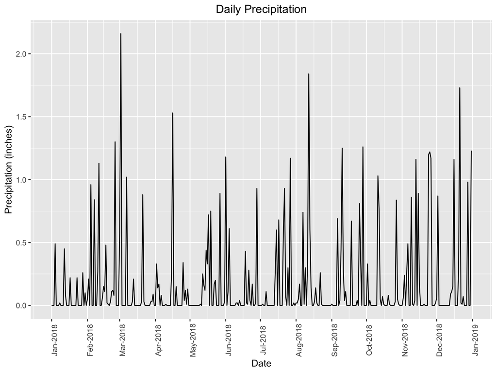

```r
ggplot(weather_nyc, mapping=aes(x=DATE, y=PRCP)) +
  geom_line() +
  scale_x_date(date_breaks = '1 month', date_labels = "%b-%Y") +
  labs(title = "Daily Precipitation",
  x = "Date",
  y = "Precipitation (inches)") +
  theme(axis.text.x = element_text(angle = 90),
  plot.title = element_text(hjust = 0.5))
```

The trend is not as clear over here. We do notice some large spikes in the graph (some months seem to have more than others) and many small spikes (indicating there are a lot of days with slight rain). Let’s take a look at the boxplot of daily precipitation across the different months.

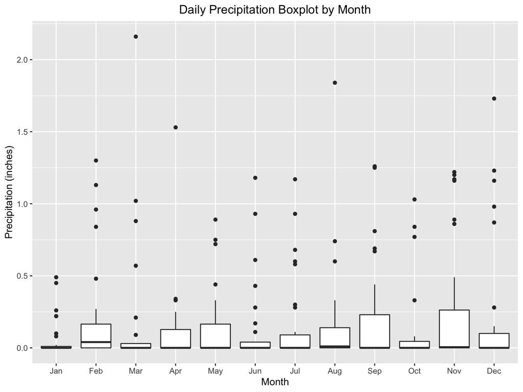

```r
ggplot(weather_nyc, mapping=aes(x=month, y=PRCP)) +
  geom_boxplot() +
  labs(title = "Daily Precipitation Boxplot by Month",
  x = "Month",
  y = "Precipitation (inches)") +
  theme(plot.title = element_text(hjust = 0.5))
```

We see more variation in some months like November and September but most medians are very close to 0, which is expected. There are a lot of outliers we see for rain and this is what we expect from a boxplot of precipitation.  
It might be more interesting to look at the percentage of days that have rain in each month of 2018. However, for this plot, we only count the days that have at least 0.1 inches of rain.

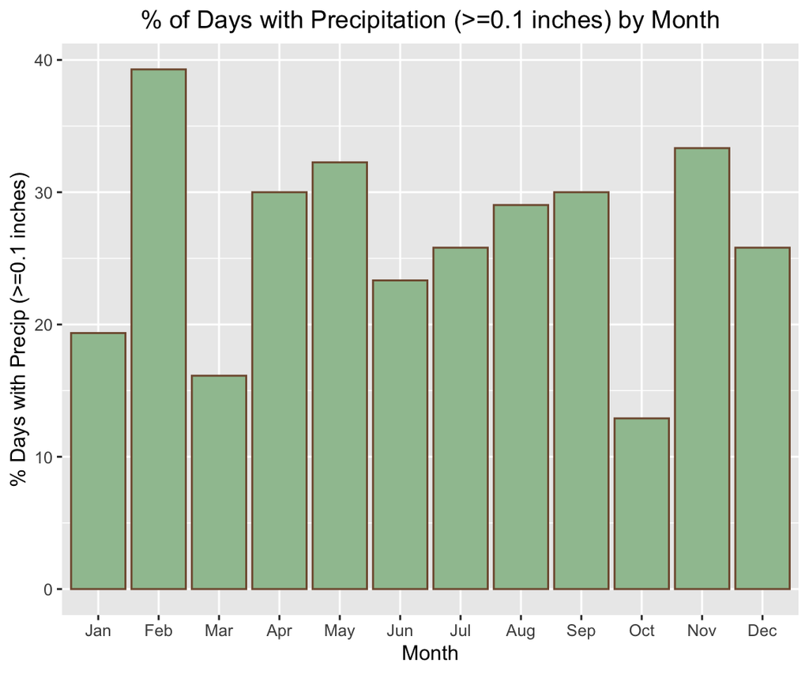

```r
weather_month <- weather_nyc %>%
  group_by(month) %>%
  summarize(num_of_days = n(),
            avg_temp = mean(TAVG),
            total_precip = sum(PRCP),
            precip_days = sum(ifelse(PRCP>=0.1,1,0)),
            snow_days = sum(ifelse(SNOW>0,1,0)))

ggplot(data=weather_month, mapping=aes(x=month, y=100*precip_days/num_of_days)) +
  geom_col(fill = "#9FC29F", color = "#80593D") +
  labs(title = "% of Days with Precipitation (>=0.1 inches) by Month",
    x = "Month",
    y = "% Days with Precip (>=0.1 inches)") +
    theme(plot.title = element_text(hjust = 0.5))
```

It seems that February had the highest % of days with rain greater than 0.1 inches across all months of the year. Note that precipitation includes drizzle, rain, sleet, snow etc.

Now that we have a good understanding of the two primary weather variables (temperature and precipitation) used in the analysis, we can move onto the citibike ridership data.

```r
citibike <- read.csv('https://raw.githubusercontent.com/harish-cu/edav_fall_2019_citibike_weather/master/data/clean/2018-citibike-summarydata.csv')

citibike <- citibike %>%
  mutate(avg_duration = avg_duration/60,
         min_duration = min_duration/60,
         max_duration = max_duration/60)

citibike <- citibike %>%
  mutate(Date = as_date(Date))

citibike_agg <- citibike %>%
  group_by(Date) %>%
  summarise(total_trip_count = sum(trip_count),
            avg_duration = sum(avg_duration*trip_count)/sum(trip_count))

citibike_weather <- citibike_agg %>%
  inner_join(weather_nyc, by=c("Date"="DATE"))
```

The very first question we’d like to address is “Does the temperature affect ridership?”. Intuitively, it makes sense for us to assume that lower temperatures lead to lower ridership. But how much of a drop do we see? Additionally, will we observe the relationship to be respected at all average temperature ranges?

To answer, we looked at a boxplot of the Daily Trip Counts by average temperature deciles. Each data point on the X axis in the below plot refers to one decile (approximately equal number of days in each bucket). Note that we have let the labels be the Temperature Range that makes up the decile as opposed to naming them as 1,2, etc in order to make sure the reader is aware of what temperature ranges we are referring to. Additionally, relabeling manually would make the graph non repeatable on a different time period of data.

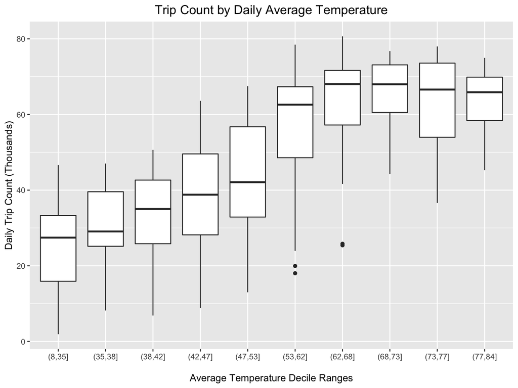

```r
citibike_weather %>%
  mutate(deciles_avg_temp = cut(x=TAVG, breaks=c(c(min(citibike_weather$TAVG-1)), quantile(citibike_weather$TAVG, seq(0.1,1, .1), include.lowest=TRUE, right=FALSE)))) %>%
  ggplot(mapping=aes(deciles_avg_temp, total_trip_count/1000)) +
  geom_boxplot() +
  labs(x="\nAverage Temperature Decile Ranges",
    y="Daily Trip Count (Thousands)",
    title="Trip Count by Daily Average Temperature") +
  theme(plot.title = element_text(size=14, hjust = 0.5))
```

We notice quite clearly that the medians of the boxplots indicating ridership increase as we go to higher deciles. However, it seems that after we pass Decile 7 (average temperature range of 62 to 68), we notice that the relationship reverses. As temperature increases the ridership drops. Our initial hypothesis was that the warmer it gets in NYC, the more open people are to use Citibike. However, this is insightful as we notice that people change their behavior not only at low temperatures but also at high temperatures. The drop in ridership in the last 3 Deciles is only small and is not anywhere as close to the increase we see when we go from low to high temperatures but there is a clear trend/relationship change (even if we assume that the riderships stops increasing at higher deciles)

We can look at a slightly different view to reinforce our understanding of the relationship between average temperature and ridership.

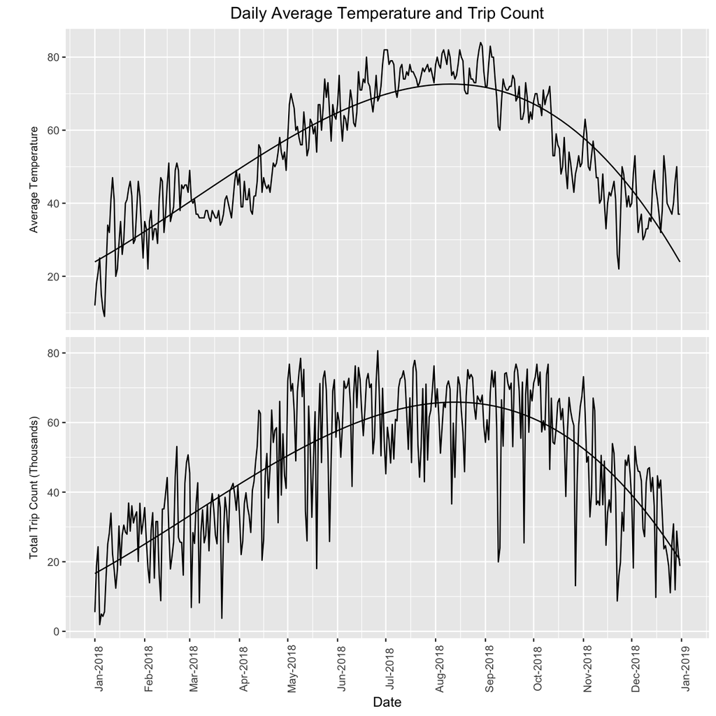

```r
citibike_weather_tidy <- citibike_weather %>%
  select(Date, total_trip_count, TAVG) %>%
  mutate(total_trip_count = total_trip_count/1000) %>%
  gather(metric, value, -Date)

citibike_weather_tidy %>%
ggplot(mapping=aes(x=Date, y=value)) +
  geom_line() + geom_smooth(method = "lm", formula = y ~ poly(x, 3), se = FALSE, color='black', size=0.5) +
  facet_wrap(metric~., ncol=1, scales='free_y',
             strip.position = "left",
             labeller = as_labeller(c(TAVG = "Average Temperature", total_trip_count = "Total Trip Count (Thousands)") ) ) +
  scale_x_date(date_breaks = '1 month', date_labels = "%b-%Y") +
  labs(title = "Daily Average Temperature and Trip Count",
  x = "Date",
  y = "") +
  theme(axis.text.x = element_text(angle = 90),
  plot.title = element_text(hjust = 0.5),
  strip.background = element_blank(),
 strip.placement = "outside")
```

This graph clearly demonstrates that the two trends pretty much mirror each other. And intuitively, we can say that the temperature influences ridership.

The very next question we want to understand is to see if temperature only affects the ride volume or if it affects trip durations as well. Do people only decide against using citibike when it is cold? Or do the people who do ride in colder weather ride for shorter durations?

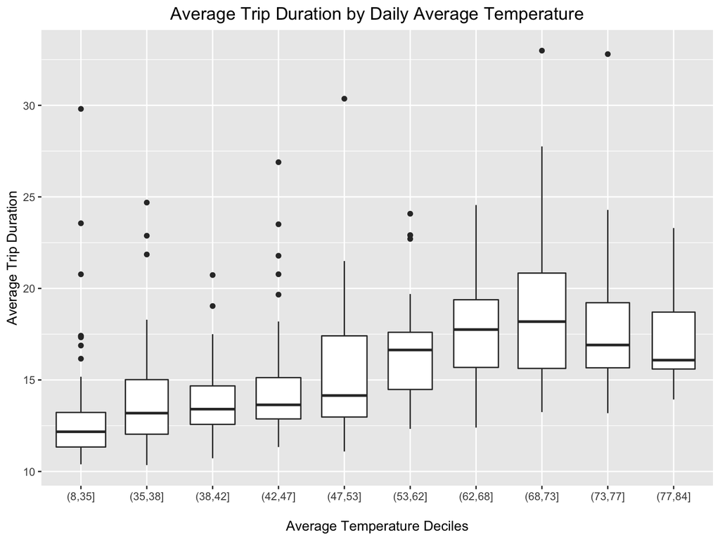

```r
citibike_weather %>%
  mutate(deciles_avg_temp = cut(x=TAVG, breaks=c(c(min(citibike_weather$TAVG-1)), quantile(citibike_weather$TAVG, seq(0.1,1, .1), include.lowest=TRUE, right=FALSE)))) %>%
  ggplot(mapping=aes(deciles_avg_temp, avg_duration)) +
  geom_boxplot(varwidth = TRUE) +
  labs(x="\nAverage Temperature Deciles",
    y="Average Trip Duration",
    title="Average Trip Duration by Daily Average Temperature") +
  theme(plot.title = element_text(size=14, hjust = 0.5))
```

We notice a trend that is quite similar to the trend in temperature. There seems to be a unimodal trend if we observe the medians. The median of the average trip duration increases as it gets warmer and then we see a slight reversal, this time after decile 8 (average temperature range of 68 to 73). So we can say that either the same riders prefer shorter rides on the cold days or we can say that only riders that have shorter trips go on citibike rides on colder days. In the future, if possible, it will be interesting to look at which of the above hypotheses is true.

The next question we want to look at is to see if precipitation affects ridership. Note that we only have the total precipitation for the day and not precipitation by the hour. So it isn’t possible to differentiate between precipitation during the day that might affect ridership and precipitation during the night that might not affect ridership. In other words, we expect that there will be some precipitation days that do not cause a drop in ridership.

First, let’s look at a boxplot of the ridership for days that had no precipitation and compare it with days that had a precipitation of at least 0.01 inches (which is the smallest measurable amount of rain).

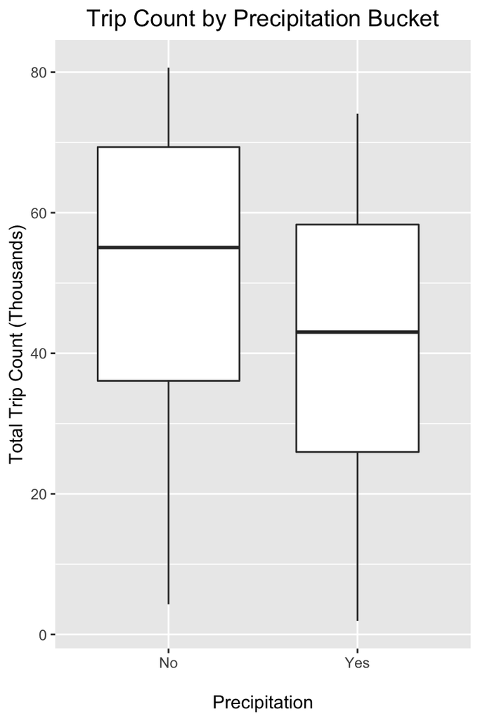

```r
citibike_weather %>%
  mutate(precip_day = as.character(ifelse(PRCP>=0.01,"Yes","No"))) %>%
  ggplot(mapping=aes(precip_day, total_trip_count/1000)) +
  geom_boxplot(varwidth = TRUE) +
  labs(x="\nPrecipitation",
    y="Total Trip Count (Thousands)",
    title="Trip Count by Precipitation Bucket") +
  theme(plot.title = element_text(size=14, hjust = 0.5))
```

It’s clear that there is a drop in ridership during precipitation days. Now, let’s get one level deeper and bucket the days into days with no precipitation, days with precipitation less than a quarter inch, days with precipitation between a quarter and one inch and days with precipitation greater than 1 inch.

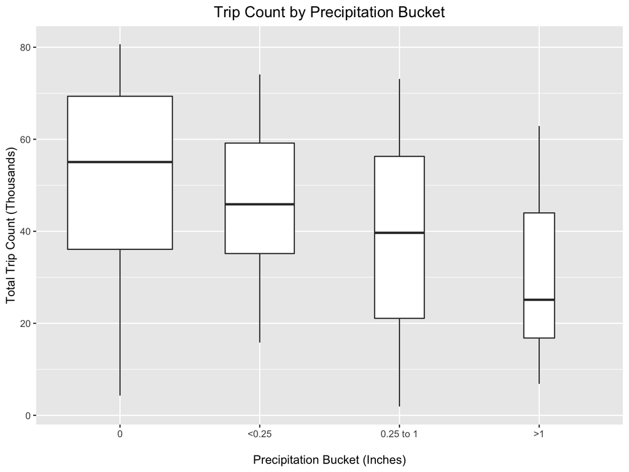

```r
citibike_weather %>%
  mutate(deciles_avg_temp = cut(x=PRCP, breaks=c(-Inf,0, 0.25, 1, +Inf))) %>%
  ggplot(mapping=aes(deciles_avg_temp, total_trip_count/1000)) +
  geom_boxplot(varwidth = TRUE) +
  scale_x_discrete(labels = c("0", "<0.25", "0.25 to 1", ">1")) +
  labs(x="\nPrecipitation Bucket (Inches)",
    y="Total Trip Count (Thousands)",
    title="Trip Count by Precipitation Bucket") +
  theme(plot.title = element_text(size=14, hjust = 0.5))
```

Let’s mark the sundays (where we’ve observed low ridership) and the days with high precipitation (over 1 inch) on the line graph of total trip count. We can check if they align with short term drops in ridership.

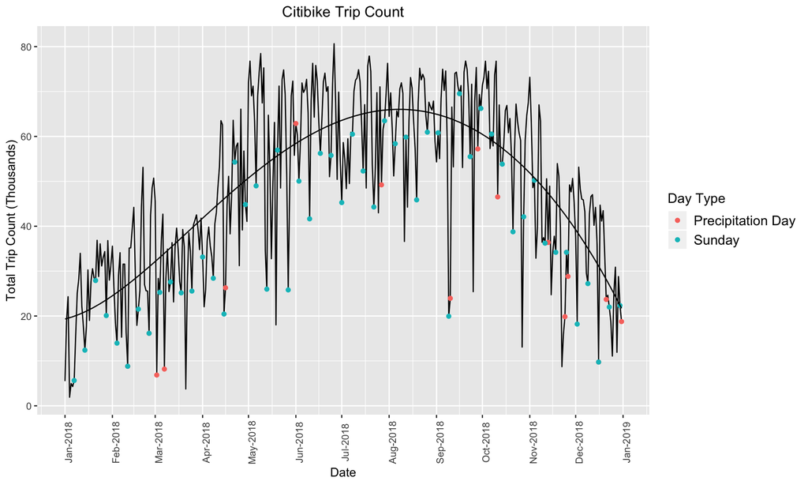

```r
citibike_weather_flag <- citibike_weather %>%
  mutate(is_precip_flag = ifelse(PRCP>1, total_trip_count, NA)) %>%
  mutate(is_weekend_flag = ifelse(is_weekend>0, total_trip_count, NA)) %>%
  mutate(is_sunday_flag = ifelse(is_sunday>0, total_trip_count, NA))

citibike_weather_flag_tidy <- citibike_weather_flag %>%
  select(Date, is_sunday_flag, is_precip_flag) %>%
  gather(metric, value, -Date) %>%
  arrange(metric)

ggplot(citibike_weather_flag, mapping=aes(x=Date, y=total_trip_count/1000)) +
  geom_line() +
  geom_point(data=citibike_weather_flag_tidy, aes(x=Date, y=value/1000, color=metric), na.rm = TRUE, alpha=1) +
  scale_x_date(date_breaks = '1 month', date_labels = "%b-%Y") +
  scale_color_discrete(name = "Day Type", labels = c("Precipitation Day", "Sunday")) +
  geom_smooth(method = "lm", formula = y ~ poly(x, 5), se = FALSE, color='black', size=0.5) +
  labs(title = "Citibike Trip Count",
  x = "Date",
  y = "Total Trip Count (Thousands)",
  color = "Day Type") +
  theme(axis.text.x = element_text(angle = 90),
  plot.title = element_text(hjust = 0.5),
  legend.position = "right",
  legend.title = element_text(size = 12),
  legend.text = element_text(size=12))
```

We can see based on the line graph that almost all days with precipitation greater than 1 inch lead to a local drop in ridership. The other local drops seem to be on sundays. This aligns with our earlier findings that precipitation causes an observable drop in ridership

Let us take a brief look at the average trip duration for each decile of temperature, but now broken out by gender. We are interested to see if there is a relationship between trip duration and gender.

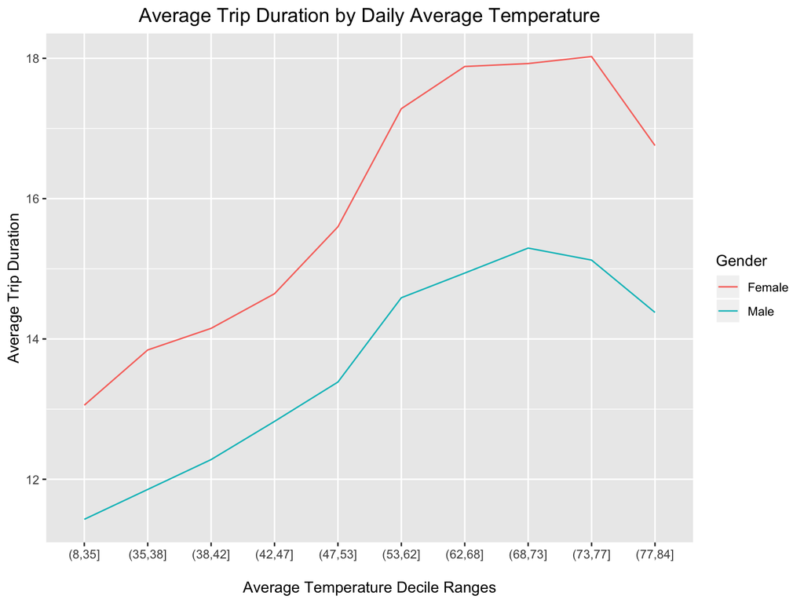

```r
gender <- read_csv('https://raw.githubusercontent.com/harish-cu/edav_fall_2019_citibike_weather/master/data/clean/2018-citibike-summarydata-age-gender.csv')

gender <- gender %>%
  mutate(avg_duration = avg_duration/60,
         min_duration = min_duration/60,
         max_duration = max_duration/60)

gender_grouped <- gender %>% group_by(date, gender) %>%
  summarise(total_trip_count = sum(trip_count),
            avg_duration = sum(avg_duration*trip_count)/sum(trip_count)) %>%
  filter(gender!=0) %>%
  mutate(gender=ifelse(gender==1, "Male", "Female"))

gender_grouped <- gender_grouped %>%
  inner_join(weather_nyc, by=c("date"="DATE"))

# Removing the outliers (incorrect values)
gender_grouped <- gender_grouped %>% filter(avg_duration<=34.09736)

gender_grouped %>%
  mutate(deciles_avg_temp = cut(x=TAVG, breaks=c(c(min(gender_grouped$TAVG-1)), quantile(gender_grouped$TAVG, seq(0.1,1, .1), include.lowest=TRUE, right=FALSE)))) %>%
  group_by(gender, deciles_avg_temp) %>%
  summarise(avg_duration = sum(avg_duration*total_trip_count)/sum(total_trip_count)) %>%
  ggplot(x, mapping=aes(deciles_avg_temp, avg_duration, group=gender)) +
  geom_line(aes(color=gender)) +
  labs(x="\nAverage Temperature Decile Ranges",
    y="Average Trip Duration",
    title="Average Trip Duration by Daily Average Temperature",
    color="Gender") +
  theme(plot.title = element_text(size=14, hjust = 0.5))
```

More importantly, we see that the gap between the two lines (Female and Male) increases with higher deciles. In other words, during warmer days, women tend to increase their trip duration more than men do.

Note:  
Since most citibike riders are the ones with annual membership, the total number of subscribers doesn’t vary wildly across months. However, it would be interesting to replot some of the above graphs just based on consumers (although we don’t expect it to vary by much)

## 6. Interactive Component

We have used parallel cooridinate plot to interactively understand the relationship between multiple weather variables and citibike ridership together.

```r
citibike_weather_temp<- citibike_weather %>% mutate(WEEK = week(Date))
names(citibike_weather_temp)[2]<-"CB_TRIP_COUNT"

citibike_weather_temp <- citibike_weather_temp %>%
  group_by(WEEK) %>%
  summarise(CB_TRIP_COUNT=sum(CB_TRIP_COUNT), TAVG=mean(TAVG), PRCP=mean(PRCP), SNOW=mean(SNOW))

citibike_weather_temp[,c('PRCP','CB_TRIP_COUNT','TAVG','SNOW', 'WEEK')] %>%
  parcoords(rownames = F , brushMode = "1D-axes", reorderable = T, queue = T, alpha=0.5,
            color = list(colorBy = "WEEK", colorScale = "scaleOrdinal", colorScheme = "schemeCategory10"),
            withD3 = TRUE)
```

[interactive chart not shown]

Some of our earlier findings are further solidified using parallel coordinate plot as now we can see multivariable relationships. We have grouped the data at the weekly level. Crossing lines between CB_TRIP_COUNT and TAVG when average temperature is on the higher side indicates drop in ridership as temperature rises, which is as per expectation. Similarly, Weeks with low average temperature shows low ridership but as temperature becomes favorable, we can see a positive correlation and ridership rises. Weeks with high precipitation and snow see big drop in ridership.

Now, let’s check and try to understand how weather changes affects Citibike and Yellowcab ridership simultaneously. Does adverse weather leads to drop in citibike rides and increae in Yellowcab rides as people might prefer to commute in a car rather in open ? Also, as weather becomes more favorable does the trend changes relatively ?

```r
yc_summary_nov <- read.csv('https://raw.githubusercontent.com/harish-cu/edav_fall_2019_citibike_weather/master/data/clean/YellowCab_2018_11_Summary.csv')

names(yc_summary_nov)[1]<-"DATE"
yc_summary_nov <- yc_summary_nov %>% mutate(DATE = as_date(DATE))

# Aggregate the KPIs at Date Level for Yellow Cab Nov Summary data
yc_summary_daily_nov <- yc_summary_nov %>%
  mutate(avg_duration = avg_duration/60,min_duration = min_duration/60,max_duration = max_duration/60) %>%
  group_by(DATE) %>%
  summarise(min_duration=min(min_duration), max_duration =max(max_duration), avg_duration=mean(avg_duration), YC_TRIP_COUNT=sum(yc_trip_count))

citibike_weather_nov <- citibike_weather %>% filter(Date>=as.Date('2018-11-01') & Date< as.Date('2018-12-01'))
names(citibike_weather_nov)[1]<-"DATE"
names(citibike_weather_nov)[2]<-"CB_TRIP_COUNT"

# Merge Yellowcab, Citibike and Weather
yc_cb_weather_merge_nov<- merge(citibike_weather_nov, yc_summary_daily_nov, by="DATE")

yc_cb_weather_merge_nov[,c('TAVG', 'CB_TRIP_COUNT', 'YC_TRIP_COUNT', 'PRCP', 'SNOW', 'DATE')] %>%
  parcoords(rownames = F , brushMode = "1D-axes", reorderable = T, queue = T, alpha=0.5,
            color = list(colorBy = "DATE", colorScale = "scaleOrdinal", colorScheme = "schemeCategory10"),
            withD3 = TRUE)
```

[interactive chart not shown]

As we can see, when average temperature in on the lower side (in 40s), riders preference for Yellow cabs is much higher compared to Citibikes and this is expected. But as weather becomes favorable, even though overall Yellow cab riders are on the higher side but relatively the gap between the two shrinks. We can see trend where demand for Citibikes rises and yellow cab decreases. Also, on the rainy and snowy days, as expected demand of Yellow Cabs are relatively higher compared to Citibikes.

Additionally, we have created a Shiny Dashboard that allows the user to explore the bike readership patterns interactively. We believe the user will be able to appreciate the effects of weather on ridership through a discovery process embedded inside the app. Here is the link to the app:

https://vgangireddy.shinyapps.io/EDAVShinyWeb/

## 7. Conclusion

To conclude, our analysis has identified some of the patterns for Weather’s impact on Citibike/Yellow Cab ridership. These can be used by New Yorkers to plan their daily routine and even by the tourists visiting the city.

*Key Takeaways:*

While it was super exciting to work on this project, there were challenges and we have some limitations in our analysis. We have used only one year (2018) of data for Citibike and Weather and only one month (Nov’2018) for Yellowcab as files were huge. To give an idea, each monthly file for Yellowcab is around 750MB in size and contains 8M records. We tried using much bigger dataset with more years of coverage but ran into memory and speed issues. As a result, some of the monthly or seasonal patterns identified may need to re-calibrated against a big dataset.

As an extension to our analysis, we plan to broaden our scope by not just including more years of data but also by augmenting our datasets with additional ridership data from taxi services like Uber & Lyft. It would be nice to get insights how these new age services have changed NYC ridership landscape which was once dominated by iconic Yellow Cab.

Lastly, we would like to thank everyone who helped in making these datasets public so that they can be used in project like ours. Also, a big thanks to Prof. Joyce Robbins for her continuous support and guidance through entire course. Thank You !!